# RNA-seq analysis with DEseq2

Rui Li, Kai Hu

03/04/2020

# **Reports**

# **Step0:** load required modules and functions

**load dataClean**  
**input:**  
feature_count_table  
cutoff_count  
**output:**  
df (column renamed, filterd out rows below cutoff_count)  
matrix_cts

```r
library(dplyr)

dataClean <- function(feature_count_table, count = 10) {
  df <- read.table(feature_count_table,
                   sep = '\t',
                   header = TRUE,
                   row.names = 1)
  # Rename colnames:
  col_name <- gsub('.bam$', '', colnames(df))
  col_name <- gsub('^sorted_reads.', '', col_name)
  colnames(df) <- col_name

  # Filter out rows with low expression:
  matrix_cts <- df[, 6:ncol(df)] %>% as.matrix()
  expressionFilter <- rowSums(matrix_cts) >= count # note can't be: rowSums(matrix_cts >= count)
  df <- df[expressionFilter, ]
  matrix_cts <- matrix_cts[expressionFilter, ]
  return(list(df, matrix_cts))
}
```

**load getAnnotation**  
**input:**  
GitHub link to annotation file  
**output:**  
annFile (annotation table)

```r
getAnnotation <- function(urlpath) {
  tmp <- tempfile()
  download.file(urlpath, destfile = tmp, method = 'auto')
  return(read.table(tmp, header = TRUE))
}
```

**load getNormalization**  
**input:**  
df  
annoFile  
**output:**  
“Normalization.xlsx” (normalized counts using TPM and FPKM)

```r
library(WriteXLS)
library(scater)

getNormalization <- function(df, annoFile) {
#Raw counts
df_cts <- df[, 6:ncol(df)]
colnames(df_cts) <- paste(colnames(df_cts), 'COUNT', sep = ':')
output_df_count <- merge(annoFile, df_cts,
                         by.x = 1, by.y = 0,
                         all.y = TRUE, sort = FALSE)

#Normalize to TPM
matrix_tpm <- calculateTPM(df_cts, lengths = df$Length)
colnames(matrix_tpm) <- paste(colnames(matrix_tpm), 'TPM', sep = ':')
output_df_tpm <- merge(annoFile, matrix_tpm,
                      by.x = 1, by.y = 0,
                      all.y = TRUE, sort = FALSE)
#Normalize to FPKM
matrix_fpkm <- calculateFPKM(df_cts, lengths = df$Length)
colnames(matrix_fpkm) <- paste(colnames(matrix_fpkm), 'FPKM', sep = ':')
output_df_fpkm <- merge(annoFile, matrix_fpkm,
                      by.x = 1, by.y = 0,
                      all.y = TRUE, sort = FALSE)

#Ouput the above into one single excel file
sheets <- list(output_df_count, output_df_tpm, output_df_fpkm)
sheets_name <- c('COUNT', 'TPM', 'FPKM')
WriteXLS(x = sheets,
         ExcelFileName = 'Normalization.xlsx',
         row.names = FALSE,
         SheetNames = sheets_name,
         na = '-')
}
```

**load fitDESeq**  
**input:**  
df  
**output:**  
dds (fitted DESeq model)  
res_design (extracted experimental design)  
‘raw.dds.rds’

```r
library(dplyr)
library(DESeq2)

fitDESeq <- function(df) {
matrix_cts <- df[, 6:ncol(df)] %>% as.matrix()
sample_name <- factor(colnames(matrix_cts))

#Determine the batch info:
sample_batch <- factor(regmatches(sample_name, regexpr('batch(_|\\.|-)*[0-9]+', sample_name, ignore.case = TRUE)))
if (length(sample_batch) == 0) sample_batch <- factor(rep('batch1', length(sample_name)))
#Determine sample condition info:
tmp_no_batch <- gsub('(_|-|\\.)batch(_|\\.|-)*[0-9]+', '', sample_name, ignore.case = TRUE)
sample_condition <- factor(gsub('.[0-9]+$', '', tmp_no_batch)) # doesn't need to be factor, need to verity this
res_design <- data.frame(sample_name, sample_condition, sample_batch)

#Prepare DESeq input files:
coldata <- data.frame(row.names = sample_name,
                      sample_condition,
                      sample_batch)
#Fit one big model into DESeq:
dds <- DESeqDataSetFromMatrix(countData = matrix_cts,
                              colData = coldata,
                              design = ~ sample_condition)
dds <- DESeq(dds) # without considering batch effect
saveRDS(dds, file = 'raw.dds.rds')
return(list(dds, res_design))
}
```

**load plotQC_PCA**  
**input:**  
dds  
**output:**  
PCA plot

```r
plotQC_PCA <- function(dds) {
  vsd <- vst(dds, blind = FALSE) # must transform data first for plotting purpose

  pcaData <- plotPCA(vsd, intgroup = 'sample_condition', returnData=TRUE)
  percentVar <- round(100 * attr(pcaData, 'percentVar'))

  sample_condition <- dds$sample_condition
  sample_batch <- dds$sample_batch

  ggplot(pcaData, aes(PC1, PC2, color = sample_condition, shape = sample_condition)) +
  geom_point(size = 3) +
  xlab(paste0("PC1: ", percentVar[1], "% variance")) +
  ylab(paste0("PC2: ", percentVar[2], "% variance")) +
  geom_label_repel(aes(label = paste(sample_condition, sample_batch, sep = '_')),
                    box.padding = 0.35,
                    point.padding = 0.5,
                    segment.color = 'grey50',
                    show.legend = FALSE) + # if TRUE, legend display might not be correct
  theme_classic()
}
```

**load plotQC_cluster**  
**input:**  
dds  
**output:**  
clustering heatmap

```r
plotQC_cluster <- function(dds) {
library(RColorBrewer)
library(dplyr)
library(pheatmap)

vsd <- vst(dds, blind = FALSE) # must transform data first for plotting purpose

sampleDists <- dist(t(assay(vsd)))
sampleDistMatrix <- sampleDists %>% as.matrix()
rownames(sampleDistMatrix) <- paste(vsd$sample_condition, vsd$sample_batch, sep = '_')
colnames(sampleDistMatrix) <- NULL
colors <- colorRampPalette(rev(brewer.pal(9, "Blues")))(255)
pheatmap(sampleDistMatrix,
         clustering_distance_rows = sampleDists,
         clustering_distance_cols = sampleDists,
         col = colors)
}
```

**load plotQC_correlation**  
**input:**dds  
**output:**  
res_df (sample correlation matrix)

```r
plotQC_correlation <- function(dds) {
library(gtools)

matrix_cts <- counts(dds)
matrix_pair <- combinations(ncol(matrix_cts), 2, v = colnames(matrix_cts), repeats.allowed = FALSE)
res_df <- data.frame(sample1 = character(), sample2 = character(), cor.test.score = double())
for (i in 1:nrow(matrix_pair)) {
  res <- cor.test(matrix_cts[, matrix_pair[i, 1]], matrix_cts[, matrix_pair[i, 2]])
  row <- data.frame('sample1' = matrix_pair[i, 1],
                    'sample2' = matrix_pair[i, 2],
                    'cor.test.score' = as.numeric(res$estimate[[1]]))
  res_df <- rbind(res_df, row)
}
return(res_df)
}
```

**load summaryRes (Contrast)**  
**input:**  
res (result from DESeq2)  
contrast_name (XXX_VS_XXX)  
cutoff_pvalue  
cutoff_LFC  
**output:**  
sig_idx (table of significant DEGs)  
up_idx (table of significantly up-regulated genes)  
down_idx (table of significantly down-regulated genes)

```r
summaryRes <- function(res, contrast_name = '', cutoff_pvalue = 0.05, cutoff_LFC = 1) {
  sig_idx <- res$padj < cutoff_pvalue & abs(res$log2FoldChange) > cutoff_LFC
  sig_idx[is.na(sig_idx)] <- FALSE
  res_sig <- res[sig_idx, ]

  up_idx <- res$padj < cutoff_pvalue & res$log2FoldChange > cutoff_LFC
  up_idx[is.na(up_idx)] <- FALSE
  res_sig_up <- res[up_idx,]

  down_idx <- res$padj < cutoff_pvalue & res$log2FoldChange < -cutoff_LFC
  down_idx[is.na(down_idx)] <- FALSE
  res_sig_down <- res[down_idx,]

  return(list(sig_idx, up_idx, down_idx))
}
```

**load plotPvalueDist (Contrast)**  
**input:**  
res  
contrast_name  
**output:**  
histogram of Pvalue distribution

```r
plotPvalueDist <- function(res, contrast_name) {
hist(res$pvalue, breaks = 50, col = 'grey',
    main = paste("Histogram of p-values (un-adjusted)", contrast_name, sep = '\n'),
    xlab = 'P-value', ylab = 'Frequency')

hist(res$padj, breaks = 50, col = 'grey',
    main = paste("Histogram of Q-values (adjusted P-values)", contrast_name, sep = '\n'),
    xlab = 'Q-value', ylab = 'Frequency')
}
```

**load plotMAFig (Contrast)**  
**input:**  
res  
contrast_name  
cutoff_pvalue  
**output:**  
MA plot

```r
library(dplyr)
library(ggplot2)

plotMAFig <- function(res, contrast_name = '', cutoff_pvalue = 0.05, labelsig = FALSE, textcx = 1, ...) {
with(res,
    plot(baseMean, log2FoldChange,
        col = 'grey80', pch = 20,
        cex = .5, main = contrast_name, ...))
with(subset(res, padj < cutoff_pvalue),
    points(baseMean, log2FoldChange,
          col = 'grey40', pch = 20,
          cex = .5))
if (labelsig) {
  with(subset(res, padj < cutoff_pvalue),
      textxy(baseMean, log2FoldChange,
      labs = Gene, cex = textcx, col = 2))
  }
}
```

**load plotVolcanoFig (Contrast)**  
**input:**  
res  
contrast_name  
cutoff_pvalue  
cutoff_LFC  
annFile  
**output:**  
volcano plot

```r
library(DESeq2)
library(EnhancedVolcano)
library(gridExtra)
library(grid)
library(dplyr)

plotVolcanoFig <- function(res, xlim = 100, ylim = 1000, contrast_name = contrast_name, cutoff_pvalue = 0.05, cutoff_LFC = 1, annoFile = '') {

res <- results(dds, contrast <- contrast)
res <- merge(data.frame(res), annoFile, by.x = 0, by.y = 1, sort = FALSE)

#Set up some arbitury xlim and ylim cutoffs
res$padj[res$padj < 10^(-ylim)] <- 10^(-ylim)
res$log2FoldChange[res$log2FoldChange > xlim] <- xlim
res$log2FoldChange[res$log2FoldChange < -xlim] <- -xlim

subset_positive <- subset(res, padj < cutoff_pvalue & log2FoldChange > cutoff_LFC)
num_positive <- dim(subset_positive)[1]

subset_negative <- subset(res, padj < cutoff_pvalue & log2FoldChange < -cutoff_LFC)
num_negative <- dim(subset_negative)[1]

plot_title <- paste("Volcano plot: ",
                    contrast_name,
                    paste("Up: ", num_positive,
                          " Down: ", num_negative,
                          sep = ''),
                    sep = '\n')

cutoff_label <- res$padj[order(res$padj)][100] # set a cutoff for labelling purpose

plot_volcano <-
  EnhancedVolcano(res, lab = res$Name,
                 x = 'log2FoldChange', y = 'padj',
                 xlab = bquote(~Log[2]~ "Fold Change"),
                 ylab = bquote(~-Log[10]~ italic(Qvalue)),
                 title = plot_title,
                 pCutoff = cutoff_pvalue, FCcutoff = cutoff_LFC,
                 #pLabellingCutoff = cutoff_label,
                 cutoffLineType = 'twodash',
                 cutoffLineWidth = 0.8,
                 pointSize = 1.0,
                 labSize = 2.0,
                 colAlpha = 0.5,
                 legendLabels = c('Not Significant',
                                   paste("|LFC| > ", cutoff_LFC, sep=""),
                                   paste("Qvalue < ", cutoff_pvalue, sep=""),
                                   'Both'),
                 legendPosition = 'right',
                 legendLabSize = 10,
                 axisLabSize = 10,
                 titleLabSize = 10,
                 legendIconSize = 3.0)

grid.arrange(plot_volcano, ncol = 1,
             top = textGrob(' ', just = c('center'),
                            gp = gpar(fontsize = 32)))
grid.rect(gp = gpar(fill = NA))
}
```

**load analyzeContrast**  
**input:**  
res  
cutoff_pvalue  
cutoff_LFC  
contrast_name  
annoFile  
**output:**  
various diagnosis plots

```r
analyzeContrast <- function(res, cutoff_pvalue = 0.05, cutoff_LFC = 1, contrast_name = '', annoFile = '', raw = TRUE) {
summaryRes(res, contrast_name = contrast_name, cutoff_pvalue = cutoff_pvalue, cutoff_LFC = cutoff_LFC)
plotPvalueDist(res, contrast_name)

if (raw) {
  plotMAFig(res, cutoff_qvalue = cutoff_pvalue, main = paste("MA-plot: LFC_raw", contrast_name, sep = '\n'))
  plotVolcanoFig(res, xlim = 100, ylim = 1000,
                 contrast_name = paste(contrast_name, "LFC_raw", sep = '_'),
                 cutoff_pvalue = cutoff_pvalue,
                 cutoff_LFC = cutoff_LFC,
                 annoFile = annoFile)
  }
else {
  plotMAFig(res, cutoff_qvalue = cutoff_pvalue, main = paste("MA-plot: LFC_shrinked", contrast_name, sep = '\n'))
  plotVolcanoFig(res, xlim = 100, ylim = 1000,
                 contrast_name = paste(contrast_name, "LFC_shrinked", sep = '_'),
                 cutoff_pvalue = cutoff_pvalue,
                 cutoff_LFC = cutoff_LFC,
                 annoFile = annoFile)
  }
}
```

```r
generateOutput <- function(df, dds, annoFile) {
  library(dplyr)
  library(DESeq2)
  library(WriteXLS)

  tpm <- df[, 6:ncol(df)] %>% as.matrix() %>% calculateTPM(, df$Length) %>% data.frame()
  colnames(tpm) <- paste(colnames(tpm),"TPM",  sep = ":")
  norm_exp <- tpm

  res_df <- lfcShrink(dds, contrast = contrast, type = 'ashr') %>% as.data.frame()
  names(res_df)[2] <- "log2FoldChange_shrinked"
  names(res_df)[3] <- "lfcSE_shrinked"

  res2_df <- results(dds, contrast <- contrast) %>% as.data.frame()
  names(res2_df)[2] <- "log2FoldChange_raw"
  names(res2_df)[3] <- "lfcSE_raw"
  res2_df <- res2_df[, c(2,3)]

  res_df_combine <- merge(res_df, res2_df, by = 0, sort = F, all.x = T)
  res_df_combine <- merge(annoFile, res_df_combine, by.x=1, by.y=1, sort=F, all.y=T)
  res_df_combine <- merge(res_df_combine, norm_exp, by.x=1, by.y=0, all.x=T, sort=F)

  # For GSEA:
  rnk <- subset(res_df_combine, select = c('Name', 'log2FoldChange_shrinked'))
  colnames(rnk) <- c("# Name","log2FoldChange_shrinked")
  rnk <- rnk[order(rnk$log2FoldChange_shrinked), ]
  write.table(rnk,
              paste(contrast_name, 'rnk', sep = '.'),
              row.names = F, quote = F, sep='\t')
  # Write out csv for later analysis:
  write.csv(res_df_combine, row.names = FALSE,
            file=paste(contrast_name, 'deseq2.csv', sep = '.'))
  # Write out xlsx for users:
  WriteXLS(x = res_df_combine,
               ExcelFileName = paste(contrast_name, 'deseq2.xlsx', sep = '.'),
                                     row.names = F, SheetNames = 'sheet1', na = '-')
  WriteXLS(x = res_df_combine,
               ExcelFileName = paste(contrast_name, 'deseq2.sig.FDR', cutoff_pvalue,
                                     'LFC', cutoff_LFC, 'xlsx', sep = '.'),
                                     row.names = F, SheetNames = 'sheet1', na = '-')
}
```

Run codes below:

# **Step1**: preprocess data: feature_count > df

```r
test_data <- 'counts.gene_id.s0.strict.txt'
res <- dataClean(test_data, count = 1) # filter using count value 1
df <- res[[1]]
matrix_cts <- res[[2]] # re-calculated in other functions
```

# **Step2**: read in annotation file

```r
# from GitHub (must be raw, not zipped)
url <- 'https://raw.githubusercontent.com/hukai916/Collections/master/gencode.v29.primary_assembly.anno.txt'
annoFile <- getAnnotation(url)
```

# **Step3:** perform normalization (TPM and FPKM)

```r
getNormalization(df, annoFile)
```

Result saved in “Normalization.xlsx”

# **Step4:** prepare and fit DESeq2 model

**Please double check the experimental design:**

```r
handler <- fitDESeq(df) # Input ot DESeq2 must be unnormalized counts file
dds <- handler[[1]]
res_design <- handler[[2]]
print(res_design)
```

```
##             sample_name sample_condition sample_batch
## 1     csc_1806_batch1_1         csc_1806       batch1
## 2     csc_1806_batch2_1         csc_1806       batch2
## 3     csc_1806_batch2_2         csc_1806       batch2
## 4 non_csc_1806_batch1_1     non_csc_1806       batch1
## 5 non_csc_1806_batch1_2     non_csc_1806       batch1
```

# **Step5:** plot QC diagnosis

## Histogram of Log10(Counts) distribution

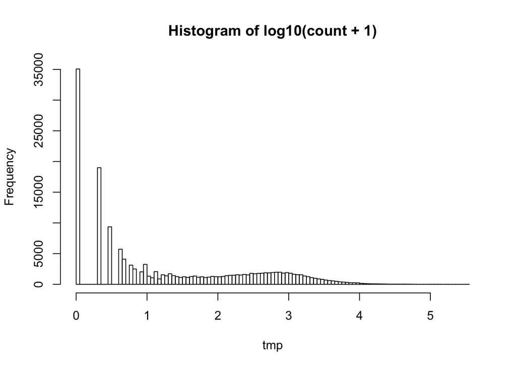

```r
library(DESeq2)

tmp <- log10(counts(dds) + 1)
hist(tmp, main = 'Histogram of log10(count + 1)', 100) # by default, use non-normalized data by counts function
```

```r
unlink(tmp)
```

## Dispersion plot

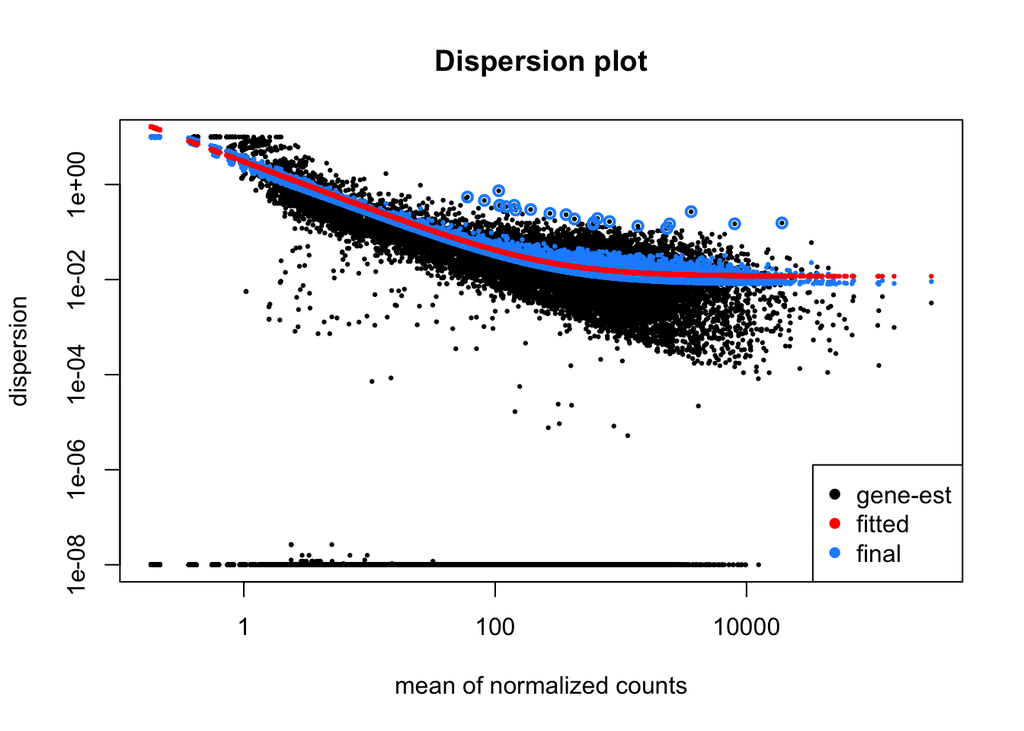

```r
plotDispEsts(dds, main = "Dispersion plot")
```

## PCA plot

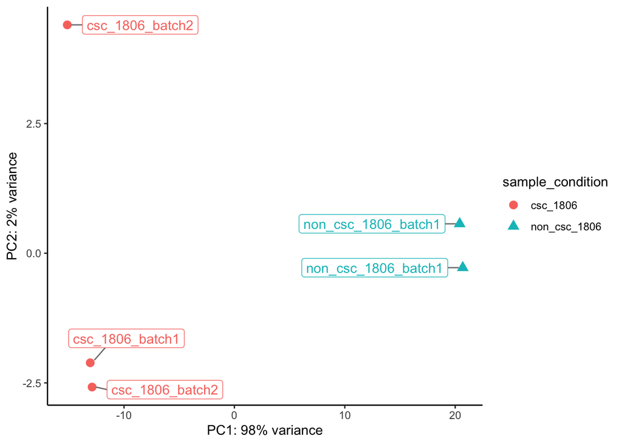

```r
plotQC_PCA(dds)
```

## Sample clustering heatmap

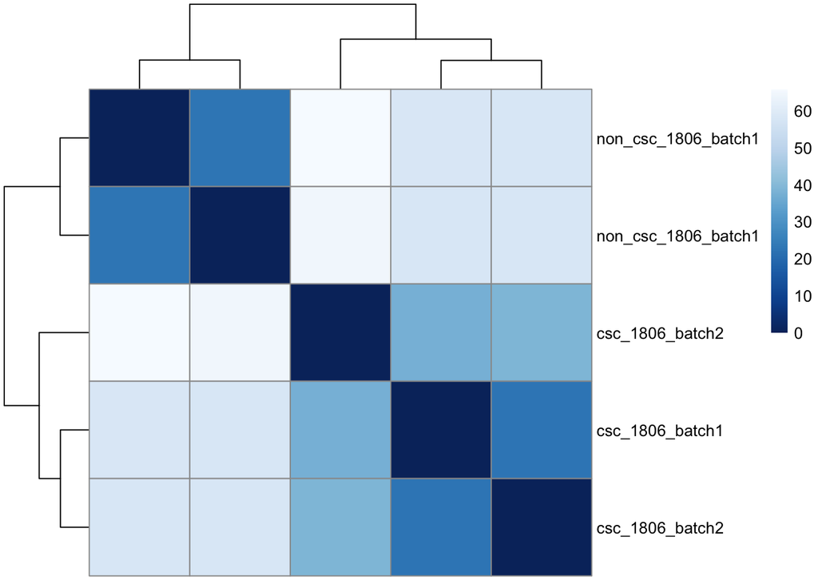

```r
plotQC_cluster(dds)
```

## Sample correlation table

```r
tmp <- plotQC_correlation(dds)
print(tmp)
```

```
##                  sample1               sample2 cor.test.score
## 1      csc_1806_batch1_1     csc_1806_batch2_1      0.9998865
## 2      csc_1806_batch1_1     csc_1806_batch2_2      0.9926146
## 3      csc_1806_batch1_1 non_csc_1806_batch1_1      0.9320671
## 4      csc_1806_batch1_1 non_csc_1806_batch1_2      0.9368571
## 5      csc_1806_batch2_1     csc_1806_batch2_2      0.9917327
## 6      csc_1806_batch2_1 non_csc_1806_batch1_1      0.9311327
## 7      csc_1806_batch2_1 non_csc_1806_batch1_2      0.9356888
## 8      csc_1806_batch2_2 non_csc_1806_batch1_1      0.9321731
## 9      csc_1806_batch2_2 non_csc_1806_batch1_2      0.9375421
## 10 non_csc_1806_batch1_1 non_csc_1806_batch1_2      0.9986650
```

```r
unlink(tmp)
```

# **Step6:** perform selected DESeq contrast

## Which contrast? Select:

```r
levels(colData(dds)$sample_condition)
```

```
## [1] "csc_1806"     "non_csc_1806"
```

## **Contrast selected:** “non_csc_1806” vs “csc_1806”

```r
cutoff_pvalue <- 0.05
cutoff_LFC <- 1
input_condition <- 'csc_1806'
target_condition <- 'non_csc_1806'
contrast <- c('sample_condition', target_condition, input_condition)
contrast_name <- paste(target_condition, '_VS_', input_condition, '(input)', sep = '')
```

## **Without shrinking**

```r
res <- results(dds, contrast = contrast)
```

### Summary tables

#### Using FDR cutoff only

```r
summary(res, alpha = cutoff_pvalue)
```

```
##
## out of 32298 with nonzero total read count
## adjusted p-value < 0.05
## LFC > 0 (up)       : 2247, 7%
## LFC < 0 (down)     : 2239, 6.9%
## outliers [1]       : 0, 0%
## low counts [2]     : 13150, 41%
## (mean count < 3)
## [1] see 'cooksCutoff' argument of ?results
## [2] see 'independentFiltering' argument of ?results
```

#### Using FDR and LFC cutoffs

```r
tmp <- summaryRes(res, contrast_name = contrast_name, cutoff_pvalue = cutoff_pvalue, cutoff_LFC = cutoff_LFC)
```

Numer of significant DEGs:

```r
table(tmp[[1]])
```

```
##
## FALSE  TRUE
## 30482  1816
```

Number of significantly up-regulated genes:

```r
table(tmp[[2]])
```

```
##
## FALSE  TRUE
## 31426   872
```

Number of significantly down-regulated genes:

```r
table(tmp[[3]])
```

```
##
## FALSE  TRUE
## 31354   944
```

### P-value distribution

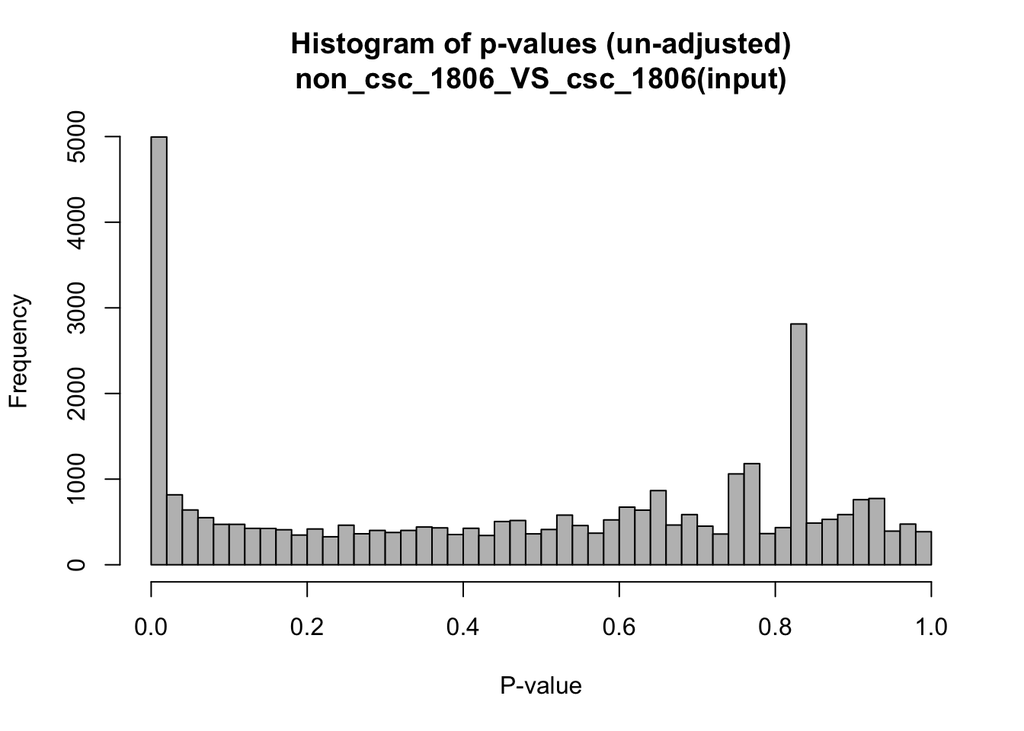

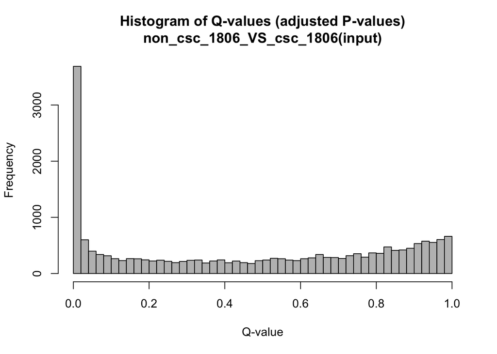

```r
plotPvalueDist(res, contrast_name)
```

### MA-plot

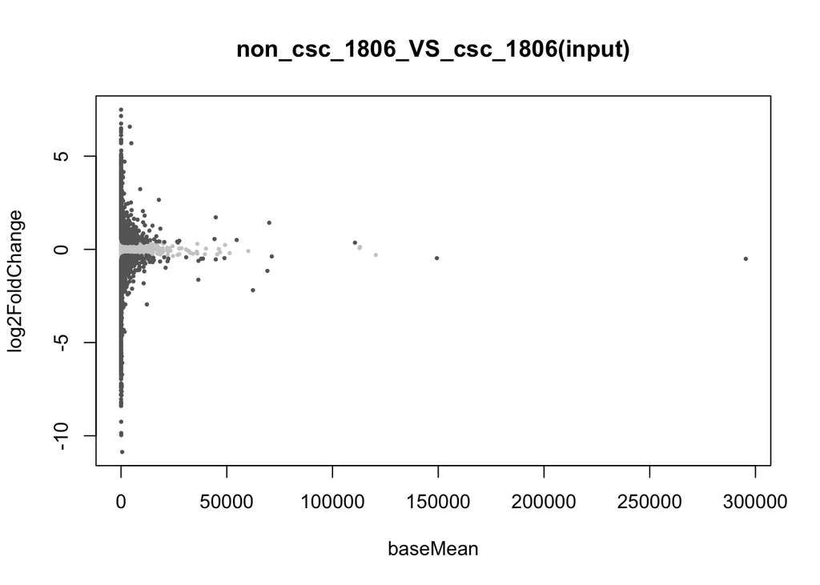

```r
plotMAFig(res, contrast_name = contrast_name, cutoff_pvalue = cutoff_pvalue, labelsig = FALSE, textcx = 1)
```

### Volcano-plot

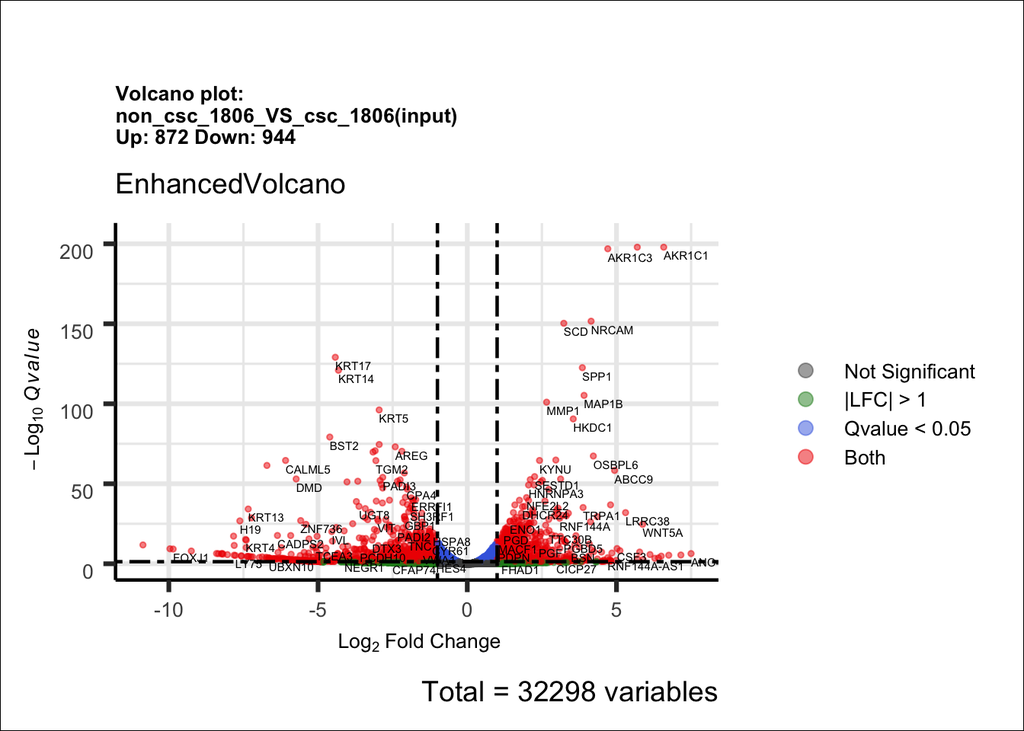

```r
plotVolcanoFig(res, xlim = 100, ylim = 1000, contrast_name = contrast_name, cutoff_pvalue = cutoff_pvalue, cutoff_LFC = cutoff_LFC, annoFile = annoFile)
```

## **With shrinking**

```r
library(ashr)

res <- lfcShrink(dds, contrast = contrast, type = 'ashr')
```

### Summary tables

#### Using FDR cutoff only

```r
summary(res, alpha = cutoff_pvalue)
```

```
##
## out of 32298 with nonzero total read count
## adjusted p-value < 0.05
## LFC > 0 (up)       : 2247, 7%
## LFC < 0 (down)     : 2239, 6.9%
## outliers [1]       : 0, 0%
## low counts [2]     : 13150, 41%
## (mean count < 3)
## [1] see 'cooksCutoff' argument of ?results
## [2] see 'independentFiltering' argument of ?results
```

#### Using FDR and LFC cutoffs

```r
tmp <- summaryRes(res, contrast_name = contrast_name, cutoff_pvalue = cutoff_pvalue, cutoff_LFC = cutoff_LFC)
```

Numer of significant DEGs:

```r
table(tmp[[1]])
```

```
##
## FALSE  TRUE
## 31002  1296
```

Number of significantly up-regulated genes:

```r
table(tmp[[2]])
```

```
##
## FALSE  TRUE
## 31687   611
```

Number of significantly down-regulated genes:

```r
table(tmp[[3]])
```

```
##
## FALSE  TRUE
## 31613   685
```

```r
unlink(tmp) # clean temporary data
```

### P-value distribution

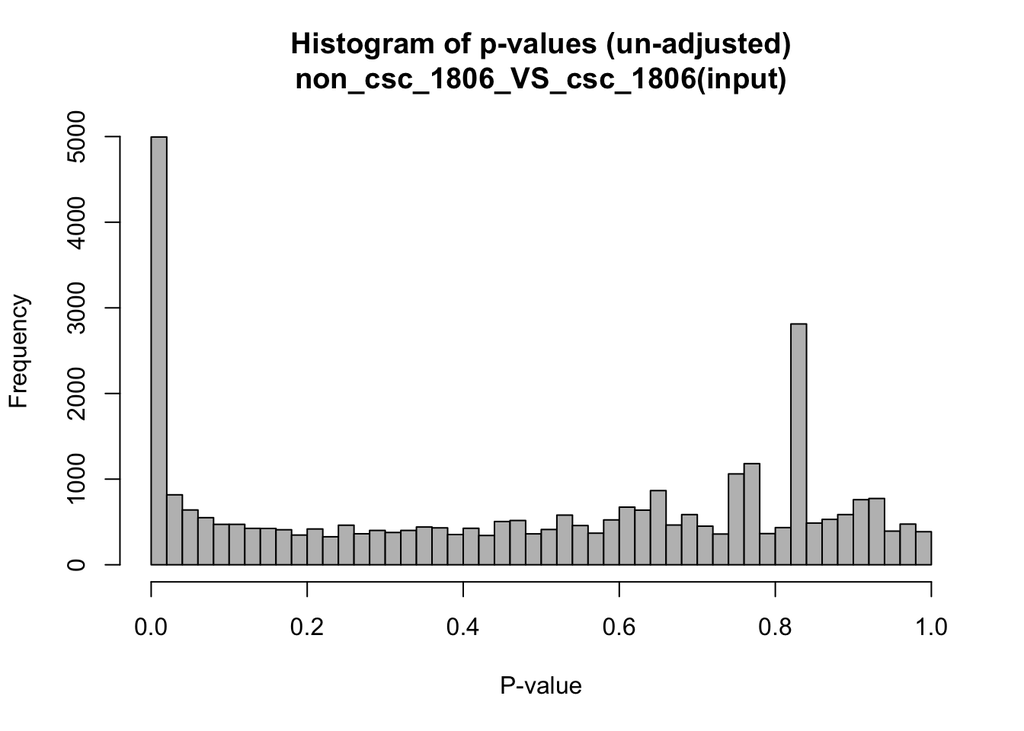

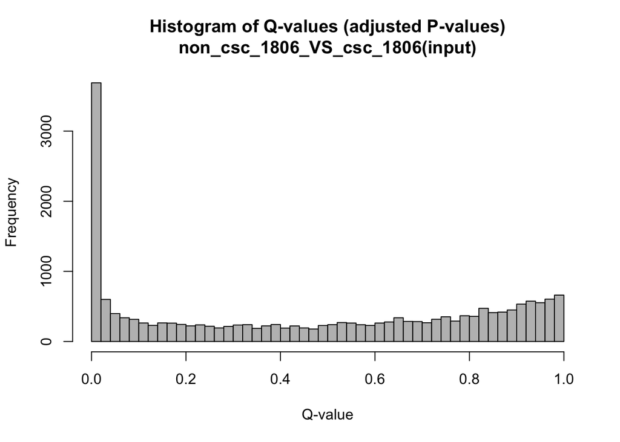

```r
plotPvalueDist(res, contrast_name)
```

### MA-plot

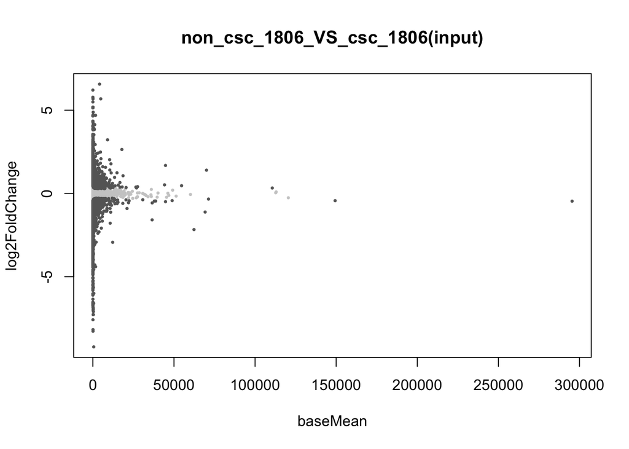

```r
plotMAFig(res, contrast_name = contrast_name, cutoff_pvalue = cutoff_pvalue, labelsig = FALSE, textcx = 1)
```

### Volcano-plot

[figure not shown]

```r
plotVolcanoFig(res, xlim = 100, ylim = 1000, contrast_name = contrast_name, cutoff_pvalue = cutoff_pvalue, cutoff_LFC = cutoff_LFC, annoFile = annoFile)
```

# **Outputs**

## “<contrast_name>.rnk”

## “<contrast_name>.deseq2.xlsx”

## “<contrast_name>.deseq2.sig.FDR.<x>.LFC.<x>.xlsx”

## “<contrast_name>.deseq2.csv”

```r
generateOutput(df, dds, annoFile)
```

# Package list

```r
(.packages())
```

```
##  [1] "ashr"                 "gtools"               "pheatmap"
##  [4] "RColorBrewer"         "grid"                 "gridExtra"
##  [7] "EnhancedVolcano"      "ggrepel"              "DESeq2"
## [10] "scater"               "ggplot2"              "SingleCellExperiment"
## [13] "SummarizedExperiment" "DelayedArray"         "BiocParallel"
## [16] "matrixStats"          "Biobase"              "GenomicRanges"
## [19] "GenomeInfoDb"         "IRanges"              "S4Vectors"
## [22] "BiocGenerics"         "parallel"             "stats4"
## [25] "WriteXLS"             "dplyr"                "stats"
## [28] "graphics"             "grDevices"            "utils"
## [31] "datasets"             "methods"              "base"
```